# Tutorial for PanelPOMP Data Analysis using Pypomp: Supplement 2 for “Mechanistic models for panel data: Analysis of ecological experiments with four interacting species”

Authors

Affiliations

Bo Yang

Department of Marketing, Columbia University

Jesse Wheeler

Department of Mathematics and Statistics, Utah State University

Meghan A. Duffy

Department of Ecology and Evolutionary Biology, University of Michigan

Aaron A. King

Department of Ecology and Evolutionary Biology, University of Michigan

Edward Ionides

Department of Statistics, University of Michigan

### Status

This tutorial extends the peer-reviewed article but is not itself peer-reviewed. It provides additional description of implementation details and data-analysis considerations that arose during the reported research. This tutorial is an accessory intended to support understanding and reproducibility.

## Introduction

Ecological experiments often yield panel time series data, wherein multiple trajectories are observed across replicated experimental units. These replicates may exhibit correlation through shared parameters governing the underlying stochastic processes. This tutorial demonstrates the construction, estimation, and validation of mechanistic models for panel data using the partially observed Markov process (POMP) framework, in the Python package [`pypomp`](https://github.com/pypomp).

We analyze panel time series data from a controlled mesocosm experiment examining the population dynamics of two freshwater zooplankton species (*Daphnia dentifera* and *D. lumholtzi*), an algal food source (*Ankistrodesmus falcatus*), and a fungal parasite historically identified as *Metschnikowia bicuspidata* and subsequently described as *Australozyma monospora* (Lachance et al. 2025). The experiment, conducted by Searle et al. (2016), was designed to investigate how interspecific competition between the native *D. dentifera* and invasive *D. lumholtzi* is modified by their different susceptibility to the parasite.

The panel iterated filter (PIF) algorithm (Bretó, Ionides, and King 2020) enables plug-and-play likelihood-based inference for general PanelPOMP models. We employ both standard PIF and its marginalized variant, MPIF, to maximize likelihood functions. Profile likelihood confidence intervals are constructed using the Monte Carlo Adjusted Profile (MCAP) method (Ionides et al. 2017; Ning, Ionides, and Ritov 2021) to account for Monte Carlo uncertainty in likelihood evaluations. General PanelPOMP notation and algorithmic details are provided in Section S2 of the Supplement.

We also evaluate competing model specifications using Akaike’s Information Criterion, $\text{AIC} = 2p - 2\ell(\hat{\theta})$, where $p$ is the number of estimated parameters and $\ell(\hat{\theta})$ is the maximized log-likelihood (Akaike 1974).

## Section 1: SRJF Model

### Experimental Design and Data Structure

The treatment consists of $U = 10$ replicated mesocosms containing *D. dentifera* populations in the absence of parasites, each observed at $N = 10$ time points $t_{u,n} = 5n + 2$ days.

**Show data processing and plotting code**

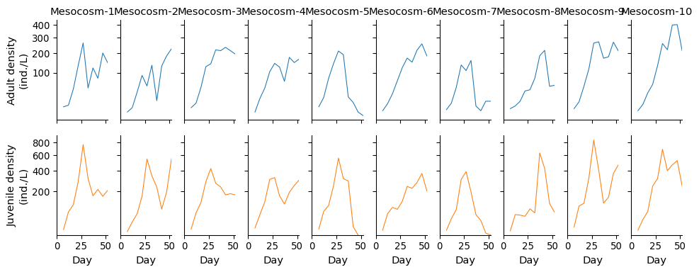

Figure 1: Observed population densities for adult (top panel) and juvenile (bottom panel) *D. dentifera* across 10 replicate mesocosms. Square-root transformation applied to y-axes for visual clarity. Each panel represents an independent experimental unit.

```python
# Load the dent-only sheet. The Excel file is in reverse chronological order
# within each rep (day 10 → day 1), so we sort (rep, day) ascending. See
# quality_reports/audits/DATA_SCHEMA.md for the full schema.
xls = pd.ExcelFile('../data/Mesocosmdata.xls')
srjf_raw = xls.parse('dent-only treatments').iloc[0:100].copy()
srjf_raw = srjf_raw.sort_values(['rep', 'day']).reset_index(drop=True)

srjf_raw['day'] = (srjf_raw['day'] - 1) * 5 + 7

srjf_data = srjf_raw[['rep', 'day', 'dent.adult', 'dent.juv']].copy()

trials = ['A', 'B', 'C', 'D', 'E', 'F', 'G', 'H', 'I', 'J']
trial_to_mesocosm = {t: f"Mesocosm {i + 1}" for i, t in enumerate(trials)}

srjf_data['Mesocosm'] = srjf_data['rep'].map(trial_to_mesocosm)
srjf_data['Mesocosm'] = pd.Categorical(
    srjf_data['Mesocosm'],
    categories=[f"Mesocosm {i + 1}" for i in range(10)],
    ordered=True,
)

srjf_data['dent.adult.plot'] = srjf_data['dent.adult']
srjf_data['dent.juv.plot'] = srjf_data['dent.juv']

fig, axes = plt.subplots(
    2, 10,
    sharex=True,
    sharey='row',
    figsize=(10, 4),
    gridspec_kw={'hspace': 0.15, 'wspace': 0.25},
)

adult_color = PALETTE["adult"]
juv_color = PALETTE["juvenile"]
line_kwargs = dict(linewidth=0.8, linestyle='-')

for j, label in enumerate([f"Mesocosm {i + 1}" for i in range(10)]):
    sub = srjf_data[srjf_data['Mesocosm'] == label]

    ax_top = axes[0, j]
    ax_bot = axes[1, j]

    ax_top.plot(sub['day'], sub['dent.adult.plot'], color=adult_color, **line_kwargs)
    ax_bot.plot(sub['day'], sub['dent.juv.plot'], color=juv_color, **line_kwargs)

    ax_top.set_title(
        label.replace('Mesocosm ', 'Mesocosm-'),
        fontsize=FONTS["panel_title"],
    )

    ax_top.set_yscale('function', functions=(np.sqrt, np.square))
    ax_bot.set_yscale('function', functions=(np.sqrt, np.square))

    for ax in (ax_top, ax_bot):
        ax.set_xlim(0, 52)
        ax.set_xticks([0, 25, 50])
        ax.tick_params(axis='both', labelsize=FONTS["tick"])
        ax.spines['top'].set_visible(False)
        ax.spines['right'].set_visible(False)

        if j != 0:
            ax.tick_params(axis='y', which='both', labelleft=False)

    if j == 0:
        ax_top.set_ylabel(
            'Adult density\n(ind./L)',
            fontsize=FONTS["panel_title"],
        )
        ax_bot.set_ylabel(
            'Juvenile density\n(ind./L)',
            fontsize=FONTS["panel_title"],
        )

    ax_bot.set_xlabel('Day', fontsize=FONTS["panel_title"])

fig.align_ylabels(axes[:, 0])
fig.subplots_adjust(left=0.07, right=0.99, top=0.92, bottom=0.13)

plt.show()
```

### Mechanistic Model

#### Model Specification

The SRJF model tracks adult *D. dentifera* ($S^n$), juveniles ($J^n$) and the algal food resource ($F$), driven by multiplicative noise on each state.

#### Biological Mechanisms

Juveniles mature into adults at rate $\lambda_J = 0.1$; adults die at rate $\theta^n_S$; reproduction is proportional to resource consumption $f^n_S F S^n$; the resource is replenished at rate $\mu = 0.37$ and diluted at $\delta = 0.013$.

#### Parameter Specification

The estimated parameters are $r^n$, $f^n_S$, $\theta^n_S$, $\theta^n_J$, $\sigma^n_J$, $\sigma_F$ and $k^n_S$. The adult process-noise scale $\sigma^n_S$ is held at zero.

### PanelPOMP Implementation Framework

#### Process Model Simulator

**Show Euler-Maruyama process simulator**

```python
# State variables tracked by the process model. `error_count` is reset at every
# observation time via Pypomp's `accumvars` mechanism.
STATENAMES = ["Sn", "Jn", "F", "T_Sn", "error_count"]

# Canonical parameter ordering used throughout this section.
PARAM_NAMES = ["rn", "f_Sn", "theta_Sn", "theta_Jn",
               "sigSn", "sigJn", "sigF", "k_Sn"]


def srjf_rproc(X_, theta_, key, covars, t, dt):
    """One Euler-Maruyama step for the SRJF model."""
    Sn, Jn, F = X_["Sn"], X_["Jn"], X_["F"]
    error_count = X_["error_count"]
    sigSn, sigJn, sigF = theta_["sigSn"], theta_["sigJn"], theta_["sigF"]
    theta_Sn, theta_Jn = theta_["theta_Sn"], theta_["theta_Jn"]
    rn, f_Sn = theta_["rn"], theta_["f_Sn"]

    # Fixed experimental constants
    delta    = 0.013   # sampling/dilution rate (day^-1)
    mu_food  = 0.37    # algal replenishment (10^6 cells L^-1 day^-1)
    lambda_J = 0.1     # juvenile maturation rate (day^-1)
    xi_J     = 1.0     # juvenile filtration ratio

    # Independent Gaussian innovations with SD * sqrt(dt)
    k1, k2, k3 = jax.random.split(key, 3)
    sqdt = jnp.sqrt(dt)
    noiSn = sigSn * sqdt * jax.random.normal(k1)
    noiJn = sigJn * sqdt * jax.random.normal(k2)
    noiF  = sigF  * sqdt * jax.random.normal(k3)

    # Deterministic + stochastic increments
    Sn_term = (lambda_J * Jn * dt
               - theta_Sn * Sn * dt
               - delta    * Sn * dt
               + Sn * noiSn)
    Jn_term = (rn * f_Sn * F * Sn * dt
               - lambda_J * Jn * dt
               - theta_Jn * Jn * dt
               - delta    * Jn * dt
               + Jn * noiJn)
    F_term  = (-f_Sn * F * (Sn + xi_J * Jn) * dt
               - delta * F * dt
               + mu_food * dt
               + F * noiF)

    Sn_new = Sn + Sn_term
    Jn_new = Jn + Jn_term
    F_new  = F  + F_term

    # Boundary rule: clamp to the nearest bound.
    Sn_violated = (Sn_new < 0.0) | (Sn_new > 1e5)
    Jn_violated = (Jn_new < 0.0) | (Jn_new > 1e5)
    F_violated  = (F_new  < 0.0) | (F_new  > 1e20)

    # Clamp to whichever boundary was violated:
    #   Sn = (Sn < 0.0) ? 0.0 : 1e5
    Sn_new = jnp.where(Sn_violated, jnp.where(Sn_new < 0.0, 0.0, 1e5),  Sn_new)
    Jn_new = jnp.where(Jn_violated, jnp.where(Jn_new < 0.0, 0.0, 1e5),  Jn_new)
    F_new  = jnp.where(F_violated,  jnp.where(F_new  < 0.0, 0.0, 1e20), F_new)

    error_count_new = (error_count
                       + jnp.where(Sn_violated, 1.0,    0.0)
                       + jnp.where(Jn_violated, 0.001,  0.0)
                       + jnp.where(F_violated,  1000.0, 0.0))

    # Non-negative observable consumed by the measurement model.
    T_Sn_new = jnp.abs(Sn_new)

    return {
        "Sn": Sn_new,
        "Jn": Jn_new,
        "F":  F_new,
        "T_Sn": T_Sn_new,
        "error_count": error_count_new,
    }
```

#### Initial State Specification

**Show initial-state specification**

```python
def srjf_rinit(theta_, key, covars, t0):
    """Deterministic initial conditions, identical across units."""
    return {
        "Sn":          jnp.array(3.0),
        "Jn":          jnp.array(0.0),
        "F":           jnp.array(16.667),
        "T_Sn":        jnp.array(0.0),
        "error_count": jnp.array(0.0),
    }
```